# Classification of news headlines with impact on the probability of stock prices changes

Max Franke

April 28, 2020

Course: CIS-627 CAPSTONE

Term: Spring/T2

# Capstone Project

## Approach

In this analysis, the following approach will be used:

### 0. Workspace preparation

- This section will clean the workspace, load the libraries, the datasets and prepare the datasets

### 1. Headline Tags

- The analysis starts with two datasets: Healines from 2019/2020 (1) and the Close stock prices from Apple (2) - Note: Later on, this approach will be rolled out for all companies in the [Dow Jones Industrial Average](https://money.cnn.com/data/dow30/)

#### Process

1. Subset the news (headline and description) for the stock symbol (e.g. “Apple”, and “AAPL”; transformation in lowercases)
2. Iterate through each headline of the subset and count the words, result: table of the most frequently mentioned tags (e.g. update)
3. Create a result dataframe: Symbol, Counts, Tag, Price Difference from minute 1 to minute 15

(3a) For each tag, the price difference from 1-15min will be calculated and to the result dataframe attanded

(3b) Check if there is a statistical difference between the time frames

### 2. Comparison of price differences

1. Most profitable time frame
2. Most profitable tag
3. Distribution of top ten tags by count

### 3. Creating input data

Predictors (x) = current close price, Volume, avg. top three tag price difference

| Variable | Example value |
| --- | --- |
| Current close price | 157.54 |
| Volume | 172 |
| FirstTag | 28.809 |
| SecondTag | 24.496 |
| ThirdTag | 23.273 |

Outcome (y) = Price difference for x min

### 4. Model Building

- Develop the convolutional neural network which takes as input the predictors
- Set the parameters: Batch size, filters, kernel size, epochs etc.
- Define structure of the network (how many layers, how many neurons, how many trials)

## Workspace preparation

### Approach

In this section the workspace will be prepared. This means that first the global environment will be cleaned, and all required packages will be loaded.

### Clean Workspace

```r
rm(list = ls())
```

### Install libraries

```r
## Install packages
my_packages <- c("plotly", "tidyverse", "reshape", "keras", "tm", "SnowballC")
#install.packages(my_packages, repos = "http://cran.rstudio.com")
```

### Load packages

```r
library(tidyverse)
library(plotly)
library(reshape)
library(keras)
library(tm)
library(SnowballC)
```

### Load news Dataset

```r
## Load data of stocks with headlines and description
setwd("/Users/MaxFranke/Desktop/05_Big Data Analytics/04_Classes/04 SP:Term2/CIS-627 CAPSTONE/News-Classification/02_Data/01_NewsApi")
news <- read.csv("News - 2019-2020.csv")
```

### Transform data

```r
# Names of dataframe
names(news) <- c("Date", "headline", "description")
news$Date <- strptime(news$Date, format = "%m/%d/%y %H:%M") + 5*60 - 5*60
knitr::kable(head(news, 3), format = "markdown")
```

| Date | headline | description |
| --- | --- | --- |
| 2019-01-20 11:11:00 | JD(U) to vote against citizenship bill in Rajya Sabha |  |
| 2019-01-20 11:17:00 | Gillibrand: Previous immigration stances weren’t ‘empathetic,’ ‘kind’ | Democratic Sen. Kirsten Gillibrand said Sunday that her previous controversial stances on immigration “certainly weren’t empathetic and they were not kind.” |
| 2019-01-20 07:47:00 | Pak name new-look team for Pro-League Hockey, drop 11 players from WC side | Pakistan selectors on Sunday effected a wholesale change in the country’s hockey squad for the FIH Pro-League series beginning next month by dropping 11 players, including captain Muhammad Rizwan, who… |

### Load APPL dataset

```r
setwd("/Users/MaxFranke/Desktop/05_Big Data Analytics/04_Classes/04 SP:Term2/CIS-627 CAPSTONE/News-Classification/02_Data/03_stocks")
apple <- read.csv("AAPL.USUSD_Candlestick_1_M_ASK_01.01.2019-01.04.2020.csv")
```

### Transform data

```r
apple$Local.time <- strptime(apple$Local.time, format = "%d.%m.%Y %H:%M")
rownames(apple) <- NULL
names(apple) <- c("Date", "Close", "Volume")
apple$Date <- apple$Date + 5*60 - 5*60
knitr::kable(head(apple, 3), format = "markdown")
```

| Date | Close | Volume |
| --- | --- | --- |
| 2019-01-01 00:00:00 | 157.767 | 0 |
| 2019-01-01 00:01:00 | 157.767 | 0 |
| 2019-01-01 00:02:00 | 157.767 | 0 |

## Headline Tags

```r
# Check if Apple or AAPL exists in headline
text_Apple_headline <- str_detect(tolower(news$headline), c("apple", "aapl"))
# Check if Apple or AAPL exists in description
text_Apple_description <- str_detect(tolower(news$description), c("apple", "aapl"))
# Summarise in one dataset
text_Apple_merge <- data.frame(headline = text_Apple_headline, description = text_Apple_description)
# Get the rows where Apple or AAPL exists
text_Apple_result <- which(text_Apple_merge[,1] == TRUE | text_Apple_merge[,2] == TRUE)

Apple <- news[text_Apple_headline,]
knitr::kable(head(Apple, 3), caption = paste("Identified news: ", nrow(Apple)), format = "markdown")
```

|  | Date | headline | description |
| --- | --- | --- | --- |
| 161 | 2019-01-08 23:09:00 | Apple Cuts First Quarter Production Plan for New iPhone Models by 10 Percent: Report | Apple is cutting planned production for its three new iPhone models by about 10 percent for the March quarter, the Nikkei Asian Review reported. |
| 219 | 2019-01-11 16:48:00 | Apple considered Samsung, MediaTek to supply 5G modems for 2019 iPhones | Apple Inc held talks with Samsung Electronics Co Ltd and MediaTek Inc along with existing vendor Intel Corp to supply 5G modem chips for 2019 iPhones, according to an Apple executive’s testimony at a … |
| 393 | 2019-01-07 06:35:00 | More Companies Are Bypassing Big App Stores, Costing Apple, Google Millions | A growing number of software companies are looking to bypass the dominant app store gatekeepers at Apple and Google. |

### Iterate through each headline and count the words

#### Step 1: Extract and then load the headlines from dataset

First, the column “headline” is extracted and saved to a txt.file. Then, this txt. file is load into R.

The following table shows the first 3 titles of this file:

| headline |
| --- |
| “Apple Cuts First Quarter Production Plan for New iPhone Models by 10 Percent: Report” |
| “Apple considered Samsung, MediaTek to supply 5G modems for 2019 iPhones” |
| “More Companies Are Bypassing Big App Stores, Costing Apple, Google Millions” |

#### Step 2: Text mining

1. Load the txt. file as a corpus

```r
# Load the data as a corpus
docs <- Corpus(VectorSource(text))
```

3. Text transformation
- Replace special characters from text

```r
toSpace <- content_transformer(function (x , pattern ) gsub(pattern, " ", x))
docs <- tm_map(docs, toSpace, "/")
docs <- tm_map(docs, toSpace, "@")
docs <- tm_map(docs, toSpace, "\\|")
```

4. Cleaning the text
- Convert the text to lower case
- Remove punctuations
- Eliminate extra white spaces
- Remove english common stopwords
- Remove the name of the stocks

```r
# Convert the text to lower case
docs <- tm_map(docs, content_transformer(tolower))
# Remove punctuations
docs <- tm_map(docs, removePunctuation)
# Eliminate extra white spaces
docs <- tm_map(docs, stripWhitespace)
# Remove english common stopwords
docs <- tm_map(docs, removeWords, stopwords("english"))
# Remove the name of the stocks
docs <- tm_map(docs, removeWords, c("apple", "apples"))
```

#### Step 3: Building a term-document matrix

A term-document matris is a table which contains the frequency of the words.

In the following table, the first 20 words of this term-document matrix are shown.

```r
dtm <- TermDocumentMatrix(docs)
dtm_matrix <- as.matrix(dtm)
dtm_vector <- sort(rowSums(dtm_matrix),decreasing=TRUE)
dtm_dataframe <- data.frame(word = names(dtm_vector),freq=dtm_vector)
rownames(dtm_dataframe) <- NULL
knitr::kable(head(dtm_dataframe, 20), format = "html")
```

| word | freq |
| --- | --- |
| update | 56 |
| iphone | 49 |
| new | 45 |
| says | 43 |
| china | 31 |
| qualcomm | 27 |
| iphones | 21 |
| will | 21 |
| app | 19 |
| business | 18 |
| news | 17 |
| sales | 17 |
| tech | 16 |
| cook | 15 |
| service | 15 |
| stocks | 14 |
| india | 14 |
| stock | 14 |
| 1apple | 14 |
| ahead | 14 |

#### Create result dataframe

```r
Apple_Result <- data.frame(Symbol = "AAPL",
                           Counts = dtm_dataframe$freq,
                           Tag = dtm_dataframe$word)
Apple_Result[, c("1","2","3","4","5","6","7","8","9","10","11","12","13","14","15")] <- NA
names(Apple_Result) <- c("Symobl", "Counts", "Tag", paste0("PD", seq(1:15)))
for (i in 4:18) {
  Apple_Result[,i] <- as.numeric(Apple_Result[,i])
}

knitr::kable(head(Apple_Result, 5), format = "markdown")
```

| Symobl | Counts | Tag | PD1 | PD2 | PD3 | PD4 | PD5 | PD6 | PD7 | PD8 | PD9 | PD10 | PD11 | PD12 | PD13 | PD14 | PD15 |
| --- | --- | --- | --- | --- | --- | --- | --- | --- | --- | --- | --- | --- | --- | --- | --- | --- | --- |
| AAPL | 56 | update | NA | NA | NA | NA | NA | NA | NA | NA | NA | NA | NA | NA | NA | NA | NA |
| AAPL | 49 | iphone | NA | NA | NA | NA | NA | NA | NA | NA | NA | NA | NA | NA | NA | NA | NA |
| AAPL | 45 | new | NA | NA | NA | NA | NA | NA | NA | NA | NA | NA | NA | NA | NA | NA | NA |
| AAPL | 43 | says | NA | NA | NA | NA | NA | NA | NA | NA | NA | NA | NA | NA | NA | NA | NA |
| AAPL | 31 | china | NA | NA | NA | NA | NA | NA | NA | NA | NA | NA | NA | NA | NA | NA | NA |

#### ITERATION

For each tag, the price difference from 1-15min will be calculated and to the result dataframe attanded

```r
for (i in 1:nrow(dtm_dataframe)) {
  # Get all rows from apple, where we can find the word i
  Apple_table <- Apple[str_detect(tolower(as.character(Apple$headline)), as.character(dtm_dataframe[i,1])),]
  # Merge the datasets
  result <- merge(Apple_table, apple, by = "Date", sort = FALSE)

  # Attand the price difference from minute 1 to minute 15 to the dataframe Apple_Result
  for (min in 1:15) {
    minute <- result$Date + min*60
    result$PriceDifference <- result$Close - apple[which(apple$Date %in% minute),2]
    sumPD <- sum(result$PriceDifference)
    Apple_Result[i,3+min] <- sumPD
  }
}

knitr::kable(head(Apple_Result, 10), format = "markdown")
```

| Symobl | Counts | Tag | PD1 | PD2 | PD3 | PD4 | PD5 | PD6 | PD7 | PD8 | PD9 | PD10 | PD11 | PD12 | PD13 | PD14 | PD15 |
| --- | --- | --- | --- | --- | --- | --- | --- | --- | --- | --- | --- | --- | --- | --- | --- | --- | --- |
| AAPL | 56 | update | 0.662 | -0.563 | -1.097 | -0.445 | -0.753 | 1.504 | 1.427 | 1.965 | 1.534 | 1.132 | 0.990 | -0.929 | -0.057 | 0.095 | -0.475 |
| AAPL | 49 | iphone | 0.099 | 0.144 | 0.206 | 0.471 | 0.751 | 0.988 | 1.101 | 1.282 | 0.814 | 0.950 | 0.568 | 0.157 | 0.329 | 0.323 | 0.195 |
| AAPL | 45 | new | 0.386 | -0.253 | -1.192 | -1.856 | -2.130 | -1.963 | -1.689 | -1.631 | -2.017 | -2.089 | -2.234 | -2.732 | -3.607 | -4.439 | -4.074 |
| AAPL | 43 | says | 0.372 | 0.061 | 0.229 | 1.016 | 1.109 | 1.083 | 1.466 | 1.002 | 1.074 | 1.466 | 0.901 | 1.055 | 1.062 | 1.232 | 0.972 |
| AAPL | 31 | china | -0.056 | -0.158 | 0.023 | 0.757 | 0.646 | 1.022 | 0.992 | 0.977 | 0.745 | 1.004 | 1.336 | 1.294 | 1.016 | 1.053 | 1.006 |
| AAPL | 27 | qualcomm | -0.234 | 0.113 | 0.511 | 0.317 | 1.143 | 1.977 | 1.658 | 2.348 | 1.938 | 1.817 | 1.652 | 0.407 | 1.015 | 1.040 | 0.597 |
| AAPL | 21 | iphones | 0.148 | 0.147 | 0.178 | 0.132 | 0.600 | 1.000 | 1.242 | 1.130 | 1.188 | 1.219 | 1.077 | 1.188 | 1.189 | 1.221 | 1.100 |
| AAPL | 21 | will | 0.067 | -0.080 | -0.054 | -0.024 | 0.311 | 0.238 | 0.337 | 0.298 | 0.238 | 0.337 | 0.273 | 0.070 | -0.064 | -0.100 | -0.182 |
| AAPL | 19 | app | 30.835 | 31.200 | 32.318 | 33.110 | 33.624 | 35.837 | 36.612 | 35.949 | 34.385 | 33.693 | 32.530 | 29.168 | 28.852 | 29.389 | 29.474 |
| AAPL | 18 | business | 0.348 | -0.550 | 0.196 | 0.442 | 0.040 | 1.371 | 0.672 | 0.098 | 0.124 | 0.036 | -0.660 | -1.370 | -1.230 | -1.947 | -2.479 |

NOTE: The tag “app” shows high price differences. But this is not really true, because in this calculation all words which include the word app are considered. So, “app” can be found in “apple” wich is unlucky :(!

#### Statistical difference between the minutes

```r
anova_df <- melt(Apple_Result, id = c("Symobl", "Counts", "Tag"))

aov <- aov(value ~ variable, data = anova_df)
summary(aov)
```

```
##                Df Sum Sq Mean Sq F value Pr(>F)
## variable       14     12  0.8485    1.01   0.44
## Residuals   22800  19157  0.8402
```

```r
TukeyHSD(aov)
```

```
##   Tukey multiple comparisons of means
##     95% family-wise confidence level
##
## Fit: aov(formula = value ~ variable, data = anova_df)
##
## $variable
##                    diff         lwr        upr     p adj
## PD2-PD1   -0.0030558843 -0.11578993 0.10967817 1.0000000
## PD3-PD1    0.0014871795 -0.11124687 0.11422123 1.0000000
## PD4-PD1    0.0071794872 -0.10555456 0.11991354 1.0000000
## PD5-PD1    0.0160151216 -0.09671893 0.12874917 1.0000000
## PD6-PD1    0.0351893491 -0.07754470 0.14792340 0.9993174
## PD7-PD1    0.0485982906 -0.06413576 0.16133234 0.9813057
## PD8-PD1    0.0430243261 -0.06970972 0.15575838 0.9941732
## PD9-PD1    0.0303609467 -0.08237310 0.14309500 0.9998766
## PD10-PD1   0.0204155161 -0.09231853 0.13314957 0.9999991
## PD11-PD1   0.0083129520 -0.10442110 0.12104700 1.0000000
## PD12-PD1  -0.0211827745 -0.13391682 0.09155128 0.9999986
## PD13-PD1  -0.0247284681 -0.13746252 0.08800558 0.9999900
## PD14-PD1  -0.0175588429 -0.13029289 0.09517521 0.9999999
## PD15-PD1  -0.0179730440 -0.13070709 0.09476101 0.9999998
## PD3-PD2    0.0045430638 -0.10819099 0.11727711 1.0000000
## PD4-PD2    0.0102353715 -0.10249868 0.12296942 1.0000000
## PD5-PD2    0.0190710059 -0.09366304 0.13180506 0.9999997
## PD6-PD2    0.0382452334 -0.07448882 0.15097928 0.9982911
## PD7-PD2    0.0516541749 -0.06107987 0.16438822 0.9679866
## PD8-PD2    0.0460802104 -0.06665384 0.15881426 0.9886042
## PD9-PD2    0.0334168310 -0.07931722 0.14615088 0.9996207
## PD10-PD2   0.0234714004 -0.08926265 0.13620545 0.9999949
## PD11-PD2   0.0113688363 -0.10136521 0.12410289 1.0000000
## PD12-PD2  -0.0181268902 -0.13086094 0.09460716 0.9999998
## PD13-PD2  -0.0216725838 -0.13440663 0.09106147 0.9999981
## PD14-PD2  -0.0145029586 -0.12723701 0.09823109 1.0000000
## PD15-PD2  -0.0149171598 -0.12765121 0.09781689 1.0000000
## PD4-PD3    0.0056923077 -0.10704174 0.11842636 1.0000000
## PD5-PD3    0.0145279421 -0.09820611 0.12726199 1.0000000
## PD6-PD3    0.0337021696 -0.07903188 0.14643622 0.9995818
## PD7-PD3    0.0471111111 -0.06562294 0.15984516 0.9859607
## PD8-PD3    0.0415371466 -0.07119690 0.15427120 0.9959225
## PD9-PD3    0.0288737673 -0.08386028 0.14160782 0.9999325
```

[output cut: 57 more lines]

```
## PD11-PD10 -0.0121025641 -0.12483661 0.10063149 1.0000000
## PD12-PD10 -0.0415982906 -0.15433234 0.07113576 0.9958605
## PD13-PD10 -0.0451439842 -0.15787803 0.06759007 0.9906415
## PD14-PD10 -0.0379743590 -0.15070841 0.07475969 0.9984175
## PD15-PD10 -0.0383885602 -0.15112261 0.07434549 0.9982208
## PD12-PD11 -0.0294957265 -0.14222978 0.08323832 0.9999127
## PD13-PD11 -0.0330414201 -0.14577547 0.07969263 0.9996670
## PD14-PD11 -0.0258717949 -0.13860584 0.08686225 0.9999825
## PD15-PD11 -0.0262859961 -0.13902005 0.08644805 0.9999786
## PD13-PD12 -0.0035456936 -0.11627974 0.10918836 1.0000000
## PD14-PD12  0.0036239316 -0.10911012 0.11635798 1.0000000
## PD15-PD12  0.0032097304 -0.10952432 0.11594378 1.0000000
## PD14-PD13  0.0071696252 -0.10556442 0.11990367 1.0000000
## PD15-PD13  0.0067554241 -0.10597863 0.11948947 1.0000000
## PD15-PD14 -0.0004142012 -0.11314825 0.11231985 1.0000000
```

There is no significant difference between the time frames.

## Tags and Price Differences

#### Most profitable time frame

```r
PD_comparison <- anova_df %>%
          dplyr::group_by(variable) %>%
          dplyr::summarize(SumOfPriceDifferences = sum(value))

knitr::kable(head(PD_comparison[order(PD_comparison$SumOfPriceDifferences, decreasing = TRUE),], 15), format = "markdown")
```

| variable | SumOfPriceDifferences |
| --- | --- |
| PD7 | 113.053 |
| PD8 | 104.575 |
| PD6 | 92.658 |
| PD9 | 85.314 |
| PD10 | 70.187 |
| PD5 | 63.494 |
| PD11 | 51.779 |
| PD4 | 50.055 |
| PD3 | 41.397 |
| PD1 | 39.135 |
| PD2 | 34.487 |
| PD14 | 12.428 |
| PD15 | 11.798 |
| PD12 | 6.916 |
| PD13 | 1.523 |

The time frame 7 minutes is the most profitable.

#### Most profitable tag

```r
profitable_word <- Apple_Result %>%
                      dplyr::group_by(Counts, Tag) %>%
                      summarize(SumOfPriceDiffernces = PD1+PD2+PD3+PD4+PD5+PD6+PD7+PD8+PD9+PD10+PD11+PD12+PD13+PD14+PD15)

knitr::kable(head(profitable_word[order(profitable_word$SumOfPriceDiffernces, decreasing = TRUE),], 15), format = "markdown")
```

| Counts | Tag | SumOfPriceDiffernces |
| --- | --- | --- |
| 19 | app | 486.976 |
| 14 | stock | 28.809 |
| 1 | race | 24.496 |
| 2 | put | 23.273 |
| 5 | wall | 22.288 |
| 2 | add | 21.987 |
| 11 | earnings | 21.076 |
| 1 | hand | 20.994 |
| 4 | investor | 20.737 |
| 8 | samsung | 19.643 |
| 2 | beats | 18.672 |
| 1 | hands | 18.464 |
| 1 | handset | 18.464 |
| 1 | innovative | 18.464 |
| 2 | premium | 18.464 |

The tag app shows the highest sum of price difference and is therefore, the most profitable

### Comparison of Time Frames concerning Price Differences

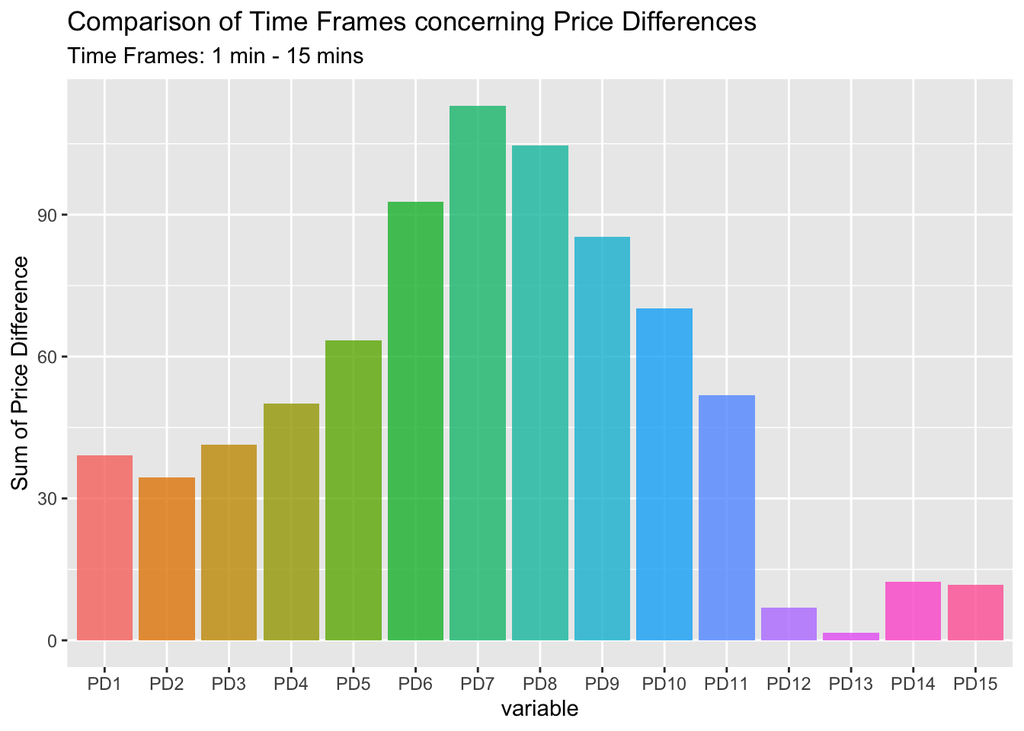

```r
ggplot(data = PD_comparison, mapping = aes(x = variable, y = SumOfPriceDifferences, fill = variable)) +
  geom_col(alpha = .8) +
  guides(fill = FALSE) +
  labs(title = "Comparison of Time Frames concerning Price Differences",
       subtitle = "Time Frames: 1 min - 15 mins",
       y = "Sum of Price Difference")
```

### Comparison of tags

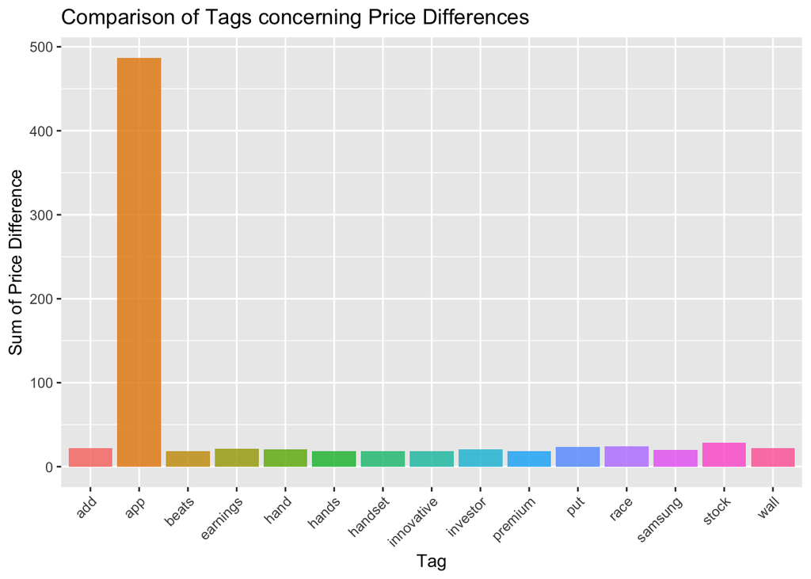

```r
ggplot(data = head(profitable_word[order(profitable_word$SumOfPriceDiffernces, decreasing = TRUE),], 15),
       mapping = aes(x = Tag, y = SumOfPriceDiffernces, fill = Tag)) +
  geom_col(alpha = .8) +
  theme(axis.text.x = element_text(angle = 45, hjust = 1)) +
  guides(fill = FALSE) +
  labs(title = "Comparison of Tags concerning Price Differences",
       y = "Sum of Price Difference")
```

### Comparison of tags (without the tag "app)

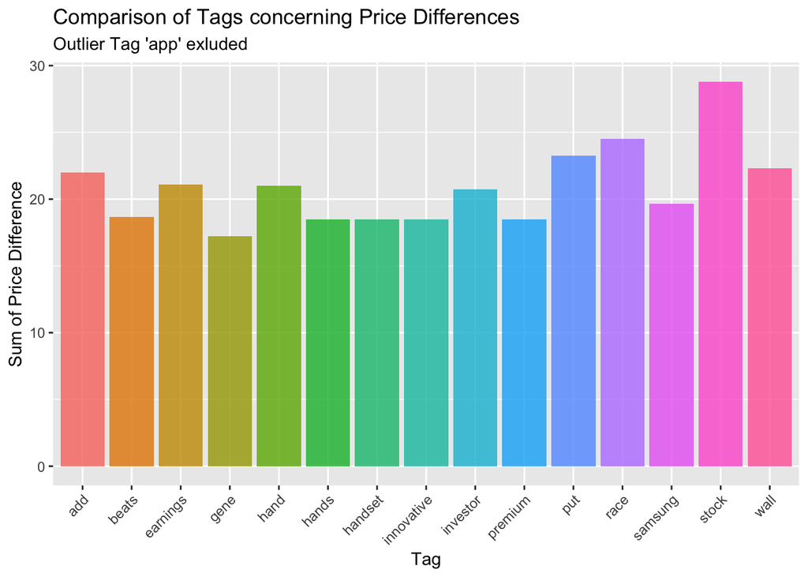

```r
ggplot(data = head(subset(profitable_word, Tag != "app")[order(subset(profitable_word, Tag != "app")$SumOfPriceDiffernces, decreasing = TRUE),], 15),
       mapping = aes(x = Tag, y = SumOfPriceDiffernces, fill = Tag)) +
  geom_col(alpha = .8) +
  theme(axis.text.x = element_text(angle = 45, hjust = 1)) +
  guides(fill = FALSE) +
  labs(title = "Comparison of Tags concerning Price Differences",
       subtitle = "Outlier Tag 'app' exluded",
       y = "Sum of Price Difference")
```

### Distribution of top Ten Tags by Count

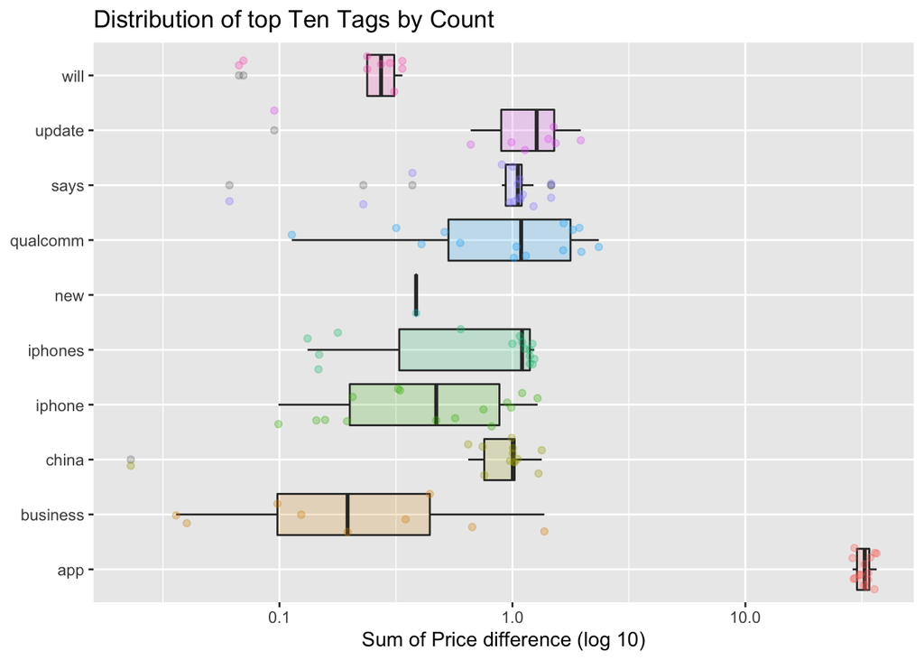

```r
plot <- melt(head(Apple_Result, 10), id = c("Symobl", "Counts", "Tag"))

ggplot(data = plot, mapping = aes(x = value, y = Tag)) +
  geom_boxplot(mapping = aes(fill = Tag), alpha = .2) +
  geom_point(mapping = aes(color = Tag), alpha = .3, position = "jitter") +
  scale_x_log10() +
  guides(fill = FALSE, color = FALSE) +
  labs(title = "Distribution of top Ten Tags by Count",
       y = NULL,
       x = "Sum of Price difference (log 10)")
```

## Creating input data

Tokenizers

```r
# converting the headlines into a sequence of integers
text <- Apple$headline
```

Number of words

```r
max_features <- 1000
tokenizer <- text_tokenizer(num_words = max_features)
```

Fit to the headlines

```r
tokenizer %>% fit_text_tokenizer(text)
```

Number of documents

```r
tokenizer$document_count
```

```
## [1] 443
```

Word-Index list

```r
tokenizer$word_index %>% head()
```

```
## $aided
## [1] 837
##
## $keybanc
## [1] 1101
##
## $all
## [1] 203
##
## $since
## [1] 786
##
## $sci
## [1] 812
##
## $forget
## [1] 1251
```

List of integers

```r
text_seqs <- texts_to_sequences(tokenizer, text)
knitr::kable(text_seqs %>% head(), format = "html")
```

| x |
| --- |
| 1 |
| 85 |
| 73 |
| 200 |
| 128 |
| 129 |
| 5 |
| 13 |
| 12 |
| 666 |
| 42 |
| 96 |
| 130 |
| 49 |

| x |
| --- |
| 1 |
| 667 |
| 97 |
| 668 |
| 2 |
| 669 |
| 56 |
| 670 |
| 5 |
| 167 |
| 29 |

| x |
| --- |
| 22 |
| 270 |
| 32 |
| 671 |
| 168 |
| 34 |
| 98 |
| 672 |
| 1 |
| 57 |
| 673 |

| x |
| --- |
| 1 |
| 74 |
| 99 |
| 169 |
| 271 |
| 22 |
| 58 |
| 674 |
| 201 |
| 272 |
| 75 |
| 43 |

| x |
| --- |
| 10 |
| 34 |
| 67 |
| 390 |
| 13 |
| 675 |
| 111 |
| 100 |
| 676 |
| 59 |
| 677 |
| 131 |
| 13 |
| 678 |
| 170 |
| 679 |

| x |
| --- |
| 10 |
| 680 |
| 391 |
| 101 |
| 50 |
| 681 |
| 40 |
| 5 |
| 19 |

## Model Building

Set parameters

```r
maxlen <- 100
batch_size <- 32
embedding_dims <- 50
filters <- 64
kernel_size <- 3
hidden_dims <- 50
epochs <- 50
```

Preprocessing the text

```r
x_train <- text_seqs %>% pad_sequences(maxlen = maxlen)
dim(x_train)
```

```
## [1] 443 100
```

y-variable

```r
y_train <- Apple_Result$PD7
length(y_train)
```

```
## [1] 1521
```

Model building

```r
model <- keras_model_sequential() %>%
  layer_embedding(max_features, embedding_dims, input_length = maxlen) %>%
  layer_dropout(0.5) %>%
  layer_conv_1d(
    filters, kernel_size,
    padding = "valid", activation = "relu", strides = 1) %>%
  layer_global_max_pooling_1d() %>%
  layer_dense(hidden_dims) %>%
  layer_dropout(0.5) %>%
  layer_activation("relu") %>%
  layer_dense(1) %>%
  layer_activation("sigmoid") %>% compile(
  loss = "binary_crossentropy",
  optimizer = "adam",
  metrics = "accuracy"
)
```

```r
#hist <- model %>%
#  fit(
#    x_train,
#    y_train,
#    batch_size = batch_size,
#    epochs = epochs,
#    validation_split = 0.8
#  )
#plot(hist)
```